# Red Wine Exploration by Mohamed Aly

This report explores a dataset containing quality and attributes for approximately 1600 red wine samples.

```
## [1] 1599   13
```

```
## 'data.frame':    1599 obs. of  13 variables:
##  $ X                   : int  1 2 3 4 5 6 7 8 9 10 ...
##  $ fixed.acidity       : num  7.4 7.8 7.8 11.2 7.4 7.4 7.9 7.3 7.8 7.5 ...
##  $ volatile.acidity    : num  0.7 0.88 0.76 0.28 0.7 0.66 0.6 0.65 0.58 0.5 ...
##  $ citric.acid         : num  0 0 0.04 0.56 0 0 0.06 0 0.02 0.36 ...
##  $ residual.sugar      : num  1.9 2.6 2.3 1.9 1.9 1.8 1.6 1.2 2 6.1 ...
##  $ chlorides           : num  0.076 0.098 0.092 0.075 0.076 0.075 0.069 0.065 0.073 0.071 ...
##  $ free.sulfur.dioxide : num  11 25 15 17 11 13 15 15 9 17 ...
##  $ total.sulfur.dioxide: num  34 67 54 60 34 40 59 21 18 102 ...
##  $ density             : num  0.998 0.997 0.997 0.998 0.998 ...
##  $ pH                  : num  3.51 3.2 3.26 3.16 3.51 3.51 3.3 3.39 3.36 3.35 ...
##  $ sulphates           : num  0.56 0.68 0.65 0.58 0.56 0.56 0.46 0.47 0.57 0.8 ...
##  $ alcohol             : num  9.4 9.8 9.8 9.8 9.4 9.4 9.4 10 9.5 10.5 ...
##  $ quality             : int  5 5 5 6 5 5 5 7 7 5 ...
```

```
##        X          fixed.acidity   volatile.acidity  citric.acid
##  Min.   :   1.0   Min.   : 4.60   Min.   :0.1200   Min.   :0.000
##  1st Qu.: 400.5   1st Qu.: 7.10   1st Qu.:0.3900   1st Qu.:0.090
##  Median : 800.0   Median : 7.90   Median :0.5200   Median :0.260
##  Mean   : 800.0   Mean   : 8.32   Mean   :0.5278   Mean   :0.271
##  3rd Qu.:1199.5   3rd Qu.: 9.20   3rd Qu.:0.6400   3rd Qu.:0.420
##  Max.   :1599.0   Max.   :15.90   Max.   :1.5800   Max.   :1.000
##  residual.sugar     chlorides       free.sulfur.dioxide
##  Min.   : 0.900   Min.   :0.01200   Min.   : 1.00
##  1st Qu.: 1.900   1st Qu.:0.07000   1st Qu.: 7.00
##  Median : 2.200   Median :0.07900   Median :14.00
##  Mean   : 2.539   Mean   :0.08747   Mean   :15.87
##  3rd Qu.: 2.600   3rd Qu.:0.09000   3rd Qu.:21.00
##  Max.   :15.500   Max.   :0.61100   Max.   :72.00
##  total.sulfur.dioxide    density             pH          sulphates
##  Min.   :  6.00       Min.   :0.9901   Min.   :2.740   Min.   :0.3300
##  1st Qu.: 22.00       1st Qu.:0.9956   1st Qu.:3.210   1st Qu.:0.5500
##  Median : 38.00       Median :0.9968   Median :3.310   Median :0.6200
##  Mean   : 46.47       Mean   :0.9967   Mean   :3.311   Mean   :0.6581
##  3rd Qu.: 62.00       3rd Qu.:0.9978   3rd Qu.:3.400   3rd Qu.:0.7300
##  Max.   :289.00       Max.   :1.0037   Max.   :4.010   Max.   :2.0000
##     alcohol         quality
##  Min.   : 8.40   Min.   :3.000
##  1st Qu.: 9.50   1st Qu.:5.000
##  Median :10.20   Median :6.000
##  Mean   :10.42   Mean   :5.636
##  3rd Qu.:11.10   3rd Qu.:6.000
##  Max.   :14.90   Max.   :8.000
```

Our dataset consists of 13 variables , with almost 1600 observations. first of all, i will try to explore each feature individually to make a clear intuition of each variable alone before exploring many features together

# Univariate Plots Section

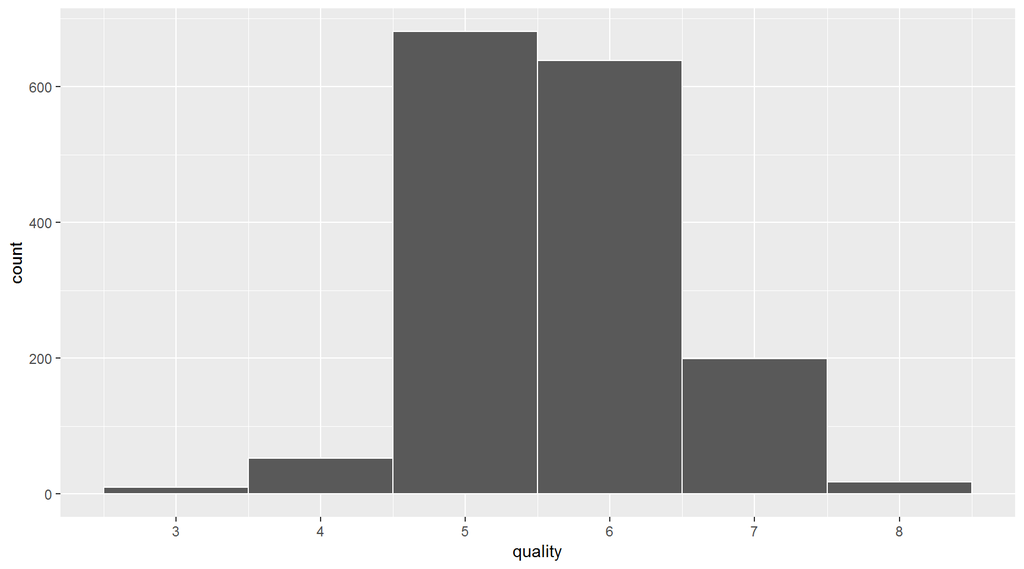

It’s clear that most wine quality is at the middle range between 5 and 6, with few number at low and high quality

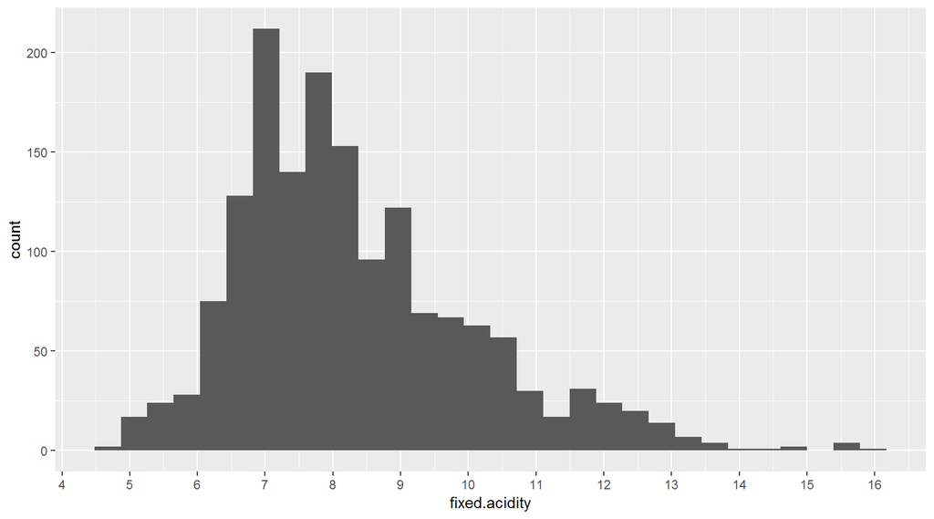

fixed acidity mostly found at 7 and 8

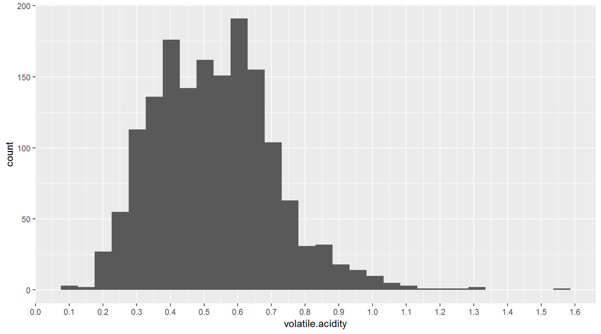

volatile acidity mostly found at 0.4 and 0.6

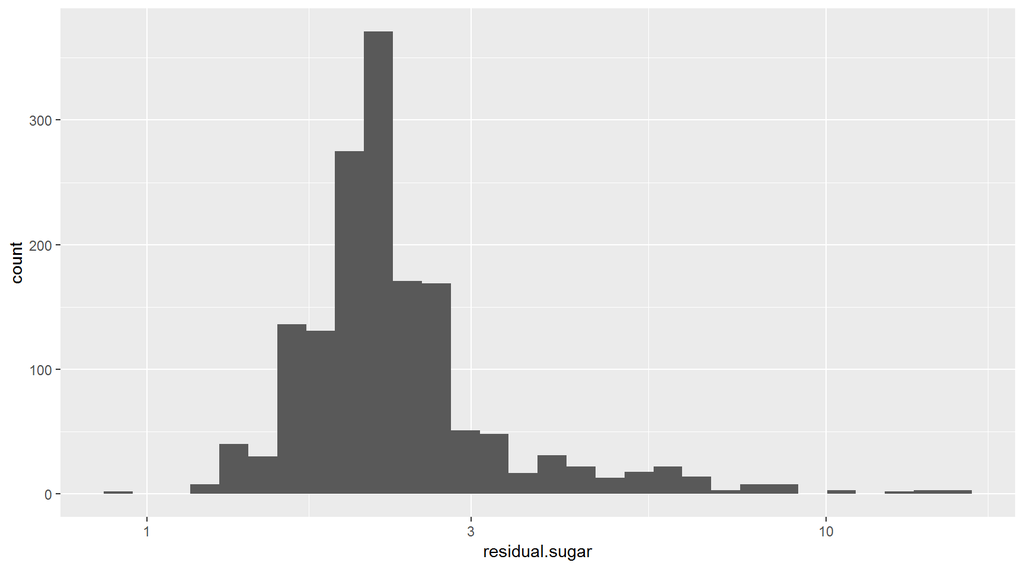

```
##
##   2 2.2 1.8 2.1 1.9 2.3
## 156 131 129 128 117 109
```

the residual sugar is mostly found to be 2, I used transformation to log scale to remove the long tail decrease in the count

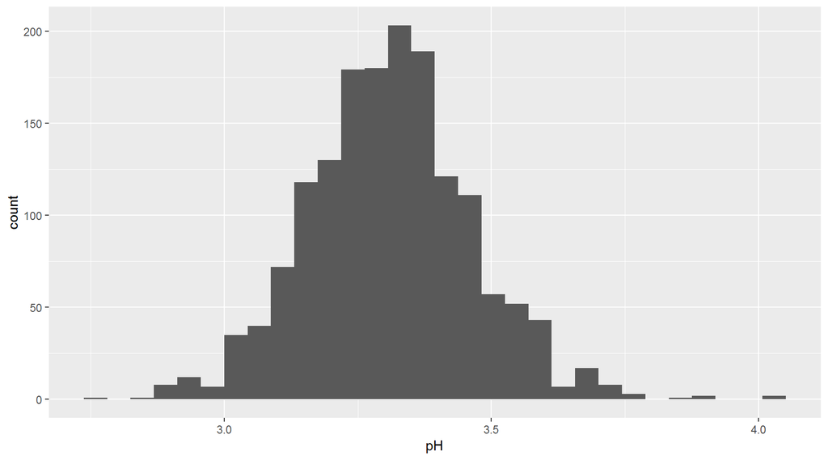

Most of the pH value is between 3 and 3.5 which is acidic

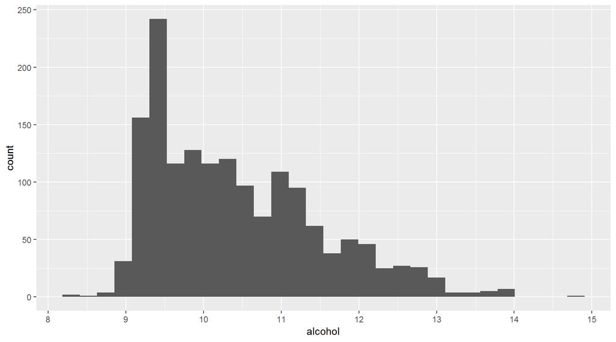

the alcoholic percentage seems to be mostly at 9.5%

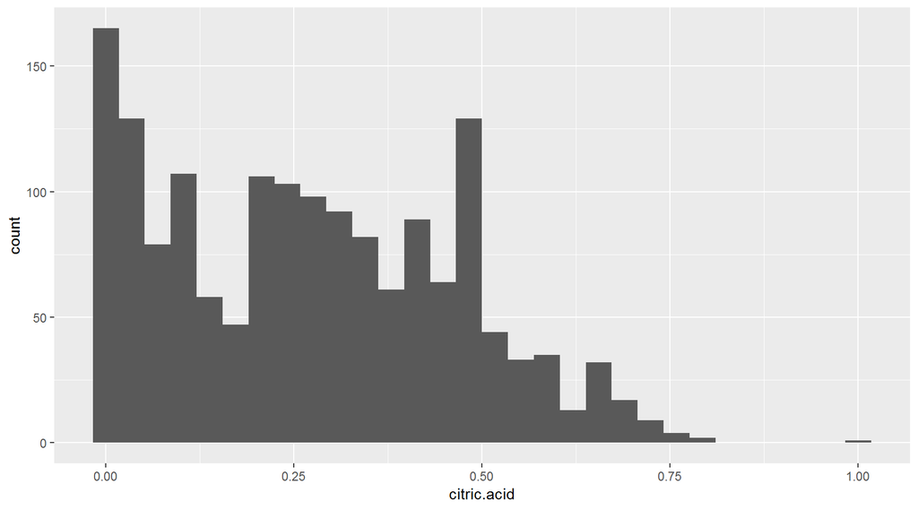

It’s clear that citric acid concentration is at low values from 0 to 0.5 approximately

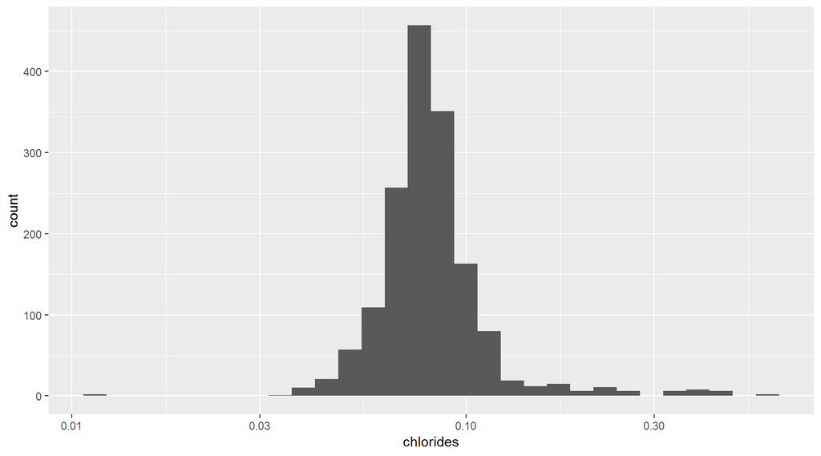

I used transformation to log scale to remove the long tail decrease in the count, it seems that it’s between 0.03 and 0.2

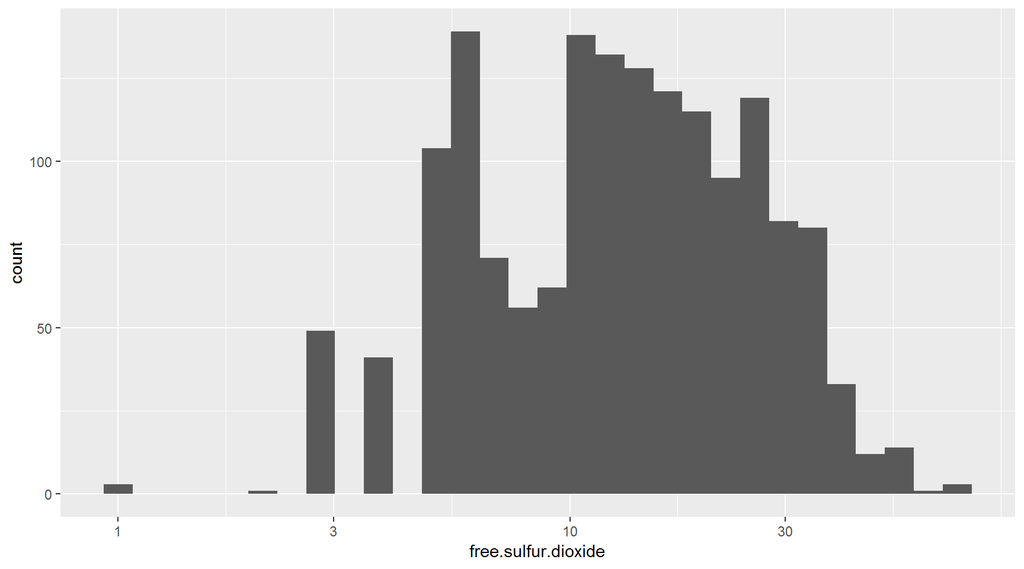

free sulphur dioxide has a wide range from 6 to about 30

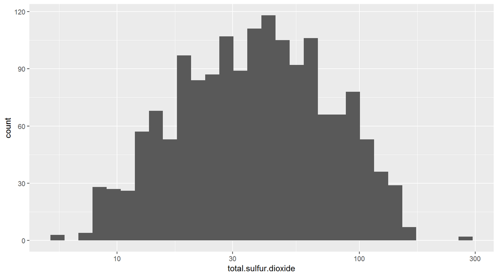

tolal sulfur dioxide have a wide range variance, I used transformation to log scale to remove the long tail decrease in the count

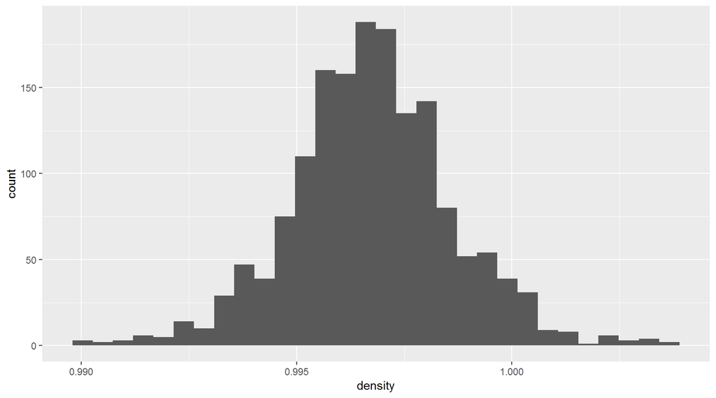

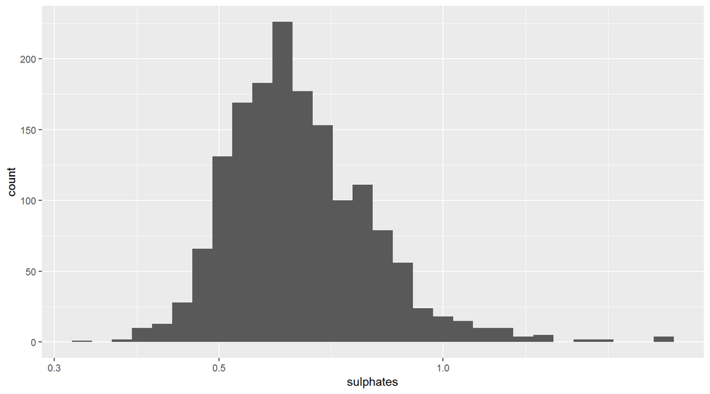

sulphates are mostly below 1, I used transformation to log scale to remove the long tail decrease in the count

# Univariate Analysis

### What is the structure of your dataset?

The dataset consists of 13 features with 1 variable as an index(X, fixed.acidity, volatile.acidity, citric.acid, residual.sugar, chlorides, free.sulfur.dioxide, total.sulfur.dioxide, density, pH, sulphates, alcohol, quality) and 1599 observations.

Observations: Most wine quality is at the middle range between 5 and 6 The alcoholic percentage seems to be mostly at 9.5% Most of the pH value is between 3 and 3.5 which is acidic

### What is/are the main feature(s) of interest in your dataset?

The main features in the data set are alcohol and quality I’d like to determine which features are best for predicting the quality of wine, I suspect alcohol and some combination of the other variables can be used to build a predictive model to quality wine.

### What other features in the dataset do you think will help support your investigation into your feature(s) of interest?

alcohol, pH, free.sulfur.dioxides, total.sulfur.dioxides, fixed.acidity, volatile.acidity, residual.sugar likely contribute to the quality of red wine. I think alcohol and fixed.acidity probably contribute most to the quality after researching information on wine quality.

### Did you create any new variables from existing variables in the dataset?

No

### Of the features you investigated, were there any unusual distributions? Did you perform any operations on the data to tidy, adjust, or change the form of the data? If so, why did you do this?

I log-transformed the right skewed sulphates, chlorides and any other right skewed distributions, to get a more suitable distribution to get a clear insight of the variable.

# Bivariate Plots Section

Here i will start to explore two features together to see the correlation between different features and how they act together.

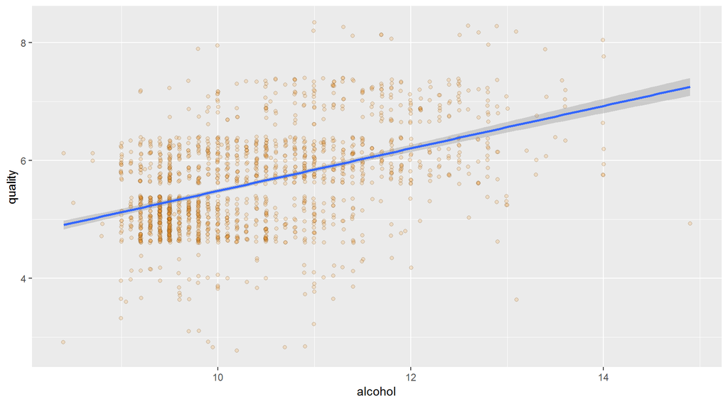

```
##
##  Pearson's product-moment correlation
##
## data:  rw$quality and rw$alcohol
## t = 21.639, df = 1597, p-value < 2.2e-16
## alternative hypothesis: true correlation is not equal to 0
## 95 percent confidence interval:
##  0.4373540 0.5132081
## sample estimates:
##       cor
## 0.4761663
```

It’s clear that for the same alcohol percentage, there is different wine quality. so, we can get that they are correlated (0.476).

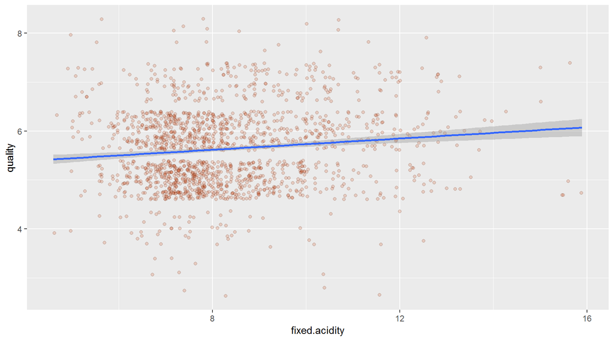

```
##
##  Pearson's product-moment correlation
##
## data:  rw$quality and rw$fixed.acidity
## t = 4.996, df = 1597, p-value = 6.496e-07
## alternative hypothesis: true correlation is not equal to 0
## 95 percent confidence interval:
##  0.07548957 0.17202667
## sample estimates:
##       cor
## 0.1240516
```

Also here, It’s clear that for the same fixed acidity, there is different wine quality. so, we can get that they are very weak correlated (0.124).

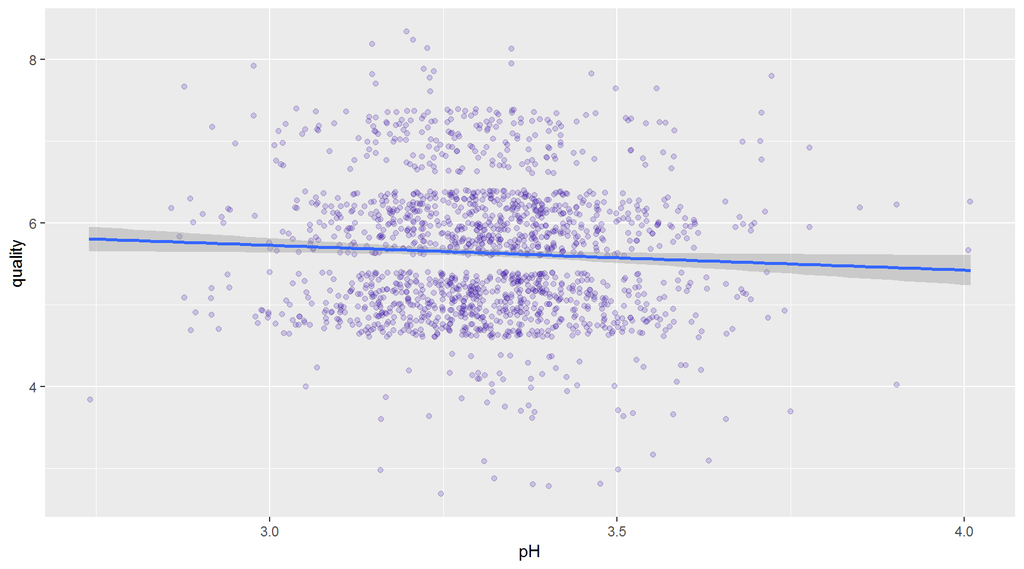

```
##
##  Pearson's product-moment correlation
##
## data:  rw$quality and rw$pH
## t = -2.3109, df = 1597, p-value = 0.02096
## alternative hypothesis: true correlation is not equal to 0
## 95 percent confidence interval:
##  -0.106451268 -0.008734972
## sample estimates:
##         cor
## -0.05773139
```

Also here, It’s clear that for the same pH value, there is different wine quality. so, we can get that they are very weak correlated (-0.057).

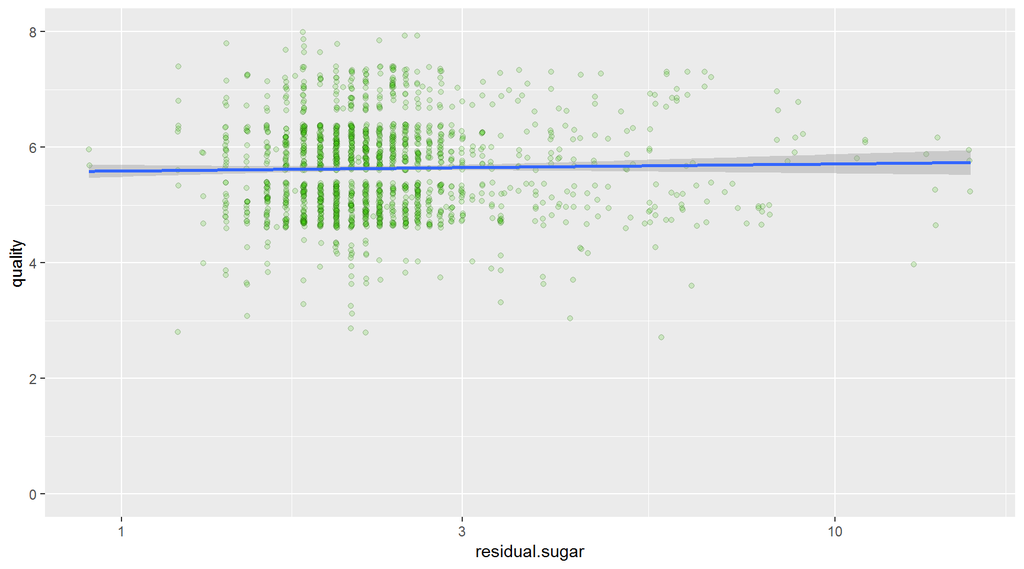

```
##
##  Pearson's product-moment correlation
##
## data:  rw$quality and rw$residual.sugar
## t = 0.5488, df = 1597, p-value = 0.5832
## alternative hypothesis: true correlation is not equal to 0
## 95 percent confidence interval:
##  -0.03531327  0.06271056
## sample estimates:
##        cor
## 0.01373164
```

Also here, It’s clear that for the same residual sugar, there is different wine quality. so, we can get that they are very weak correlated (0.013).

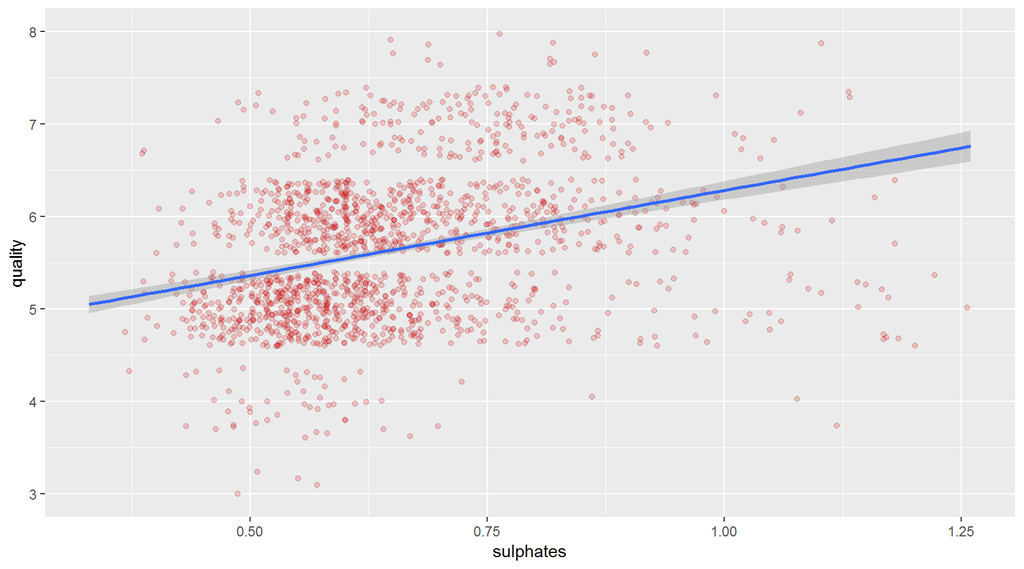

```
##
##  Pearson's product-moment correlation
##
## data:  rw$quality and rw$sulphates
## t = 10.38, df = 1597, p-value < 2.2e-16
## alternative hypothesis: true correlation is not equal to 0
## 95 percent confidence interval:
##  0.2049011 0.2967610
## sample estimates:
##       cor
## 0.2513971
```

Here for the sulphates, It’s quite different than that for residual sugar, It looks like they are quite correlated (0.251).

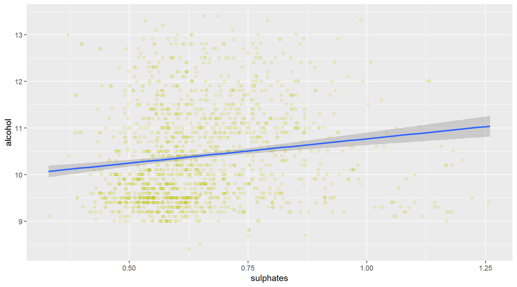

```
##
##  Pearson's product-moment correlation
##
## data:  rw$alcohol and rw$sulphates
## t = 3.7568, df = 1597, p-value = 0.0001783
## alternative hypothesis: true correlation is not equal to 0
## 95 percent confidence interval:
##  0.04477906 0.14196454
## sample estimates:
##        cor
## 0.09359475
```

It seems that they are not strongly correlated (0.093)

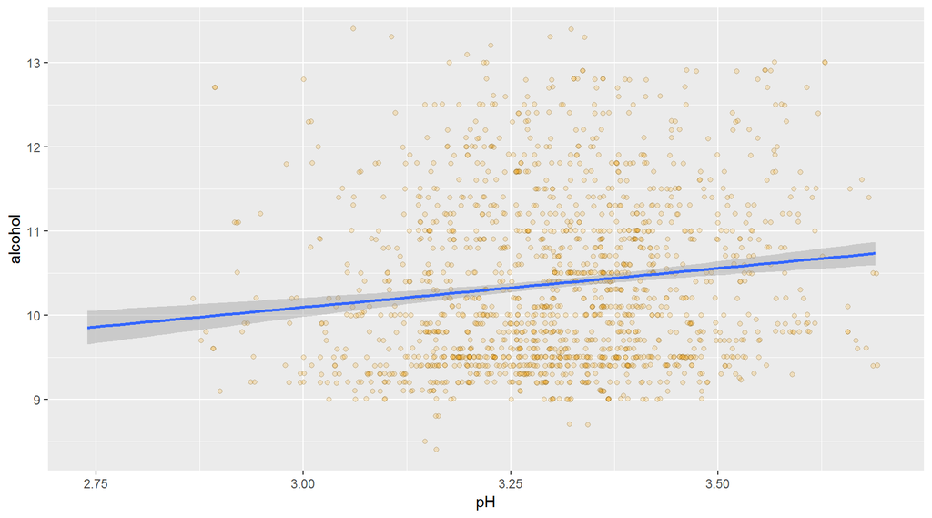

```
##
##  Pearson's product-moment correlation
##
## data:  rw$alcohol and rw$pH
## t = 8.397, df = 1597, p-value < 2.2e-16
## alternative hypothesis: true correlation is not equal to 0
## 95 percent confidence interval:
##  0.1582061 0.2521123
## sample estimates:
##       cor
## 0.2056325
```

for the values less than 7 on the pH scale, This means more acidic. so, here for 3 to 4 scale we are on acidic range.

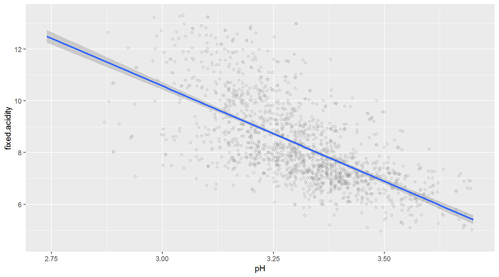

```
##
##  Pearson's product-moment correlation
##
## data:  rw$fixed.acidity and rw$pH
## t = -37.366, df = 1597, p-value < 2.2e-16
## alternative hypothesis: true correlation is not equal to 0
## 95 percent confidence interval:
##  -0.7082857 -0.6559174
## sample estimates:
##        cor
## -0.6829782
```

As the pH value increases the fixed acidity decreases which makes sense as it becomes neutral at the value of 7

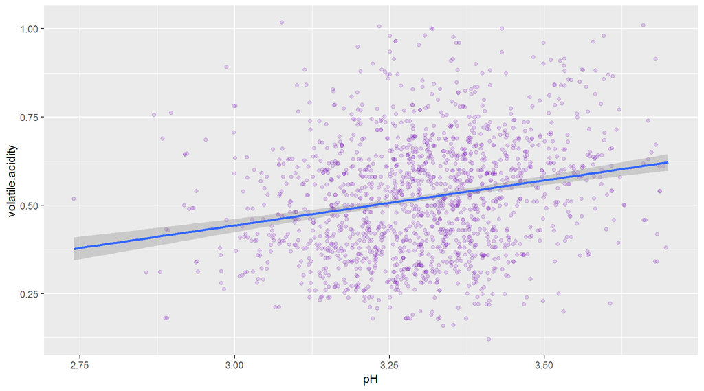

```
##
##  Pearson's product-moment correlation
##
## data:  rw$volatile.acidity and rw$pH
## t = 9.659, df = 1597, p-value < 2.2e-16
## alternative hypothesis: true correlation is not equal to 0
## 95 percent confidence interval:
##  0.1880823 0.2807254
## sample estimates:
##       cor
## 0.2349373
```

It seems to be acceptable, as it’s the opposite of the fixed acidity, we expect to see this relation even before we run the distribution.

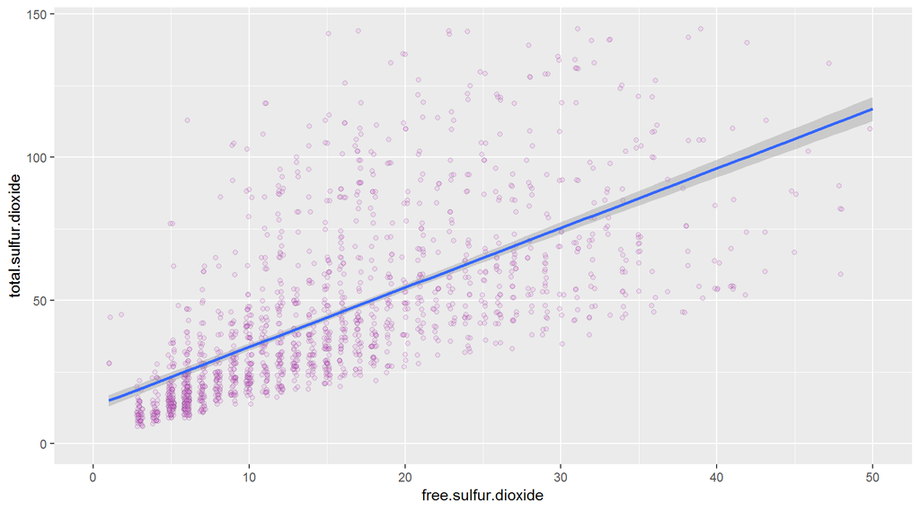

```
##
##  Pearson's product-moment correlation
##
## data:  rw$free.sulfur.dioxide and rw$total.sulfur.dioxide
## t = 35.84, df = 1597, p-value < 2.2e-16
## alternative hypothesis: true correlation is not equal to 0
## 95 percent confidence interval:
##  0.6395786 0.6939740
## sample estimates:
##       cor
## 0.6676665
```

Free sulfur dioxide is positive correlated to total sulfur dioxide (0.667)

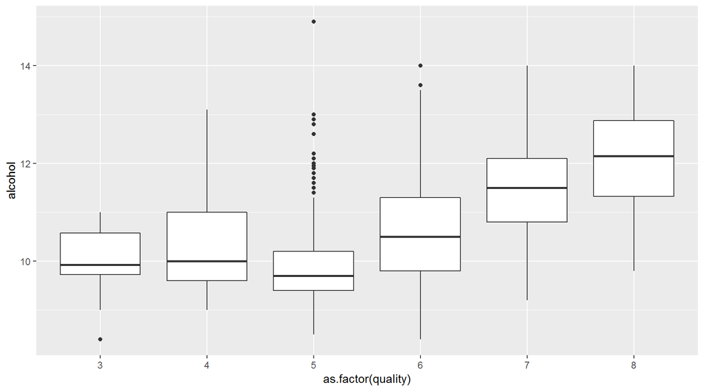

For the high quality red wine, we have high alcohol percentage. This is a strong evidence that alcoholic percentage is an indication of high quality red wine.

# Bivariate Analysis

### Did you observe any interesting relationships between the other features (not the main feature(s) of interest)?

As the pH value increases the fixed acidity decreases which makes sense as it becomes neutral at the value of 7, they are strongly negative correlated. when we change the fixed acidity with volatile acidity it becomes the opposite which makes sense.

### What was the strongest relationship you found?

The fixed acidity is negative and strongly correlated with the pH value

# Multivariate Plots Section

Now, it’s time for multiple features exploration. After what we have seen from the above distributions, we can put them all together.

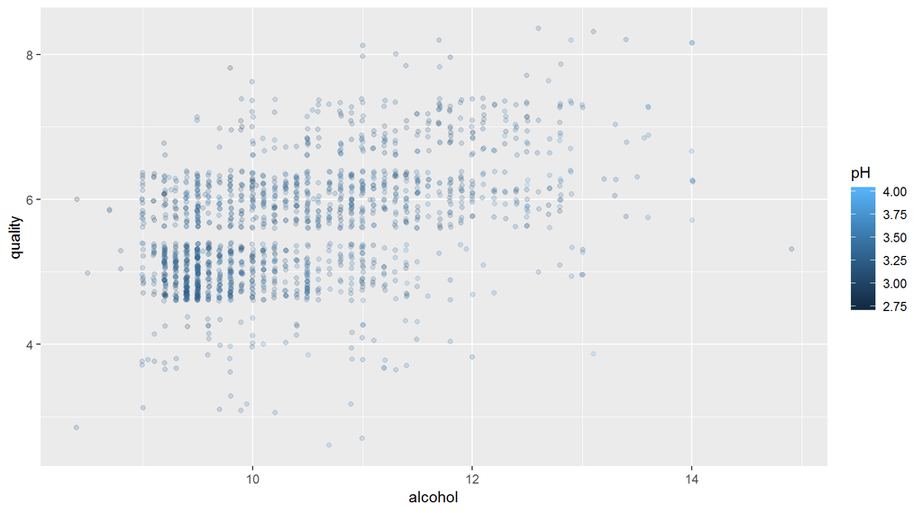

Here we see the quality and alcohol scatterplot, colored with pH relation that improve our intuition of pH feature with both of alcohol and quality.

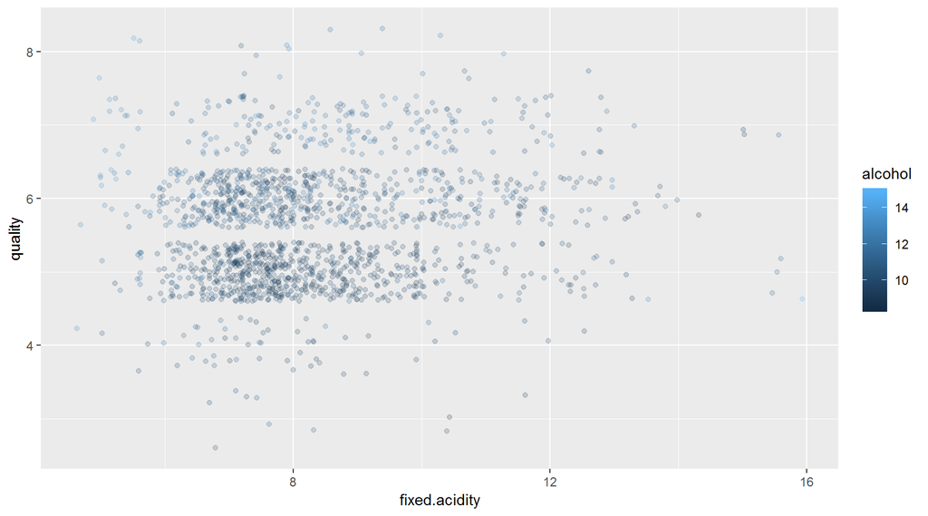

Here we see the quality and fixed acidity scatterplot, colored with alcohol relation that improve our intuition of alcohol feature with both of fixed acidity and quality.

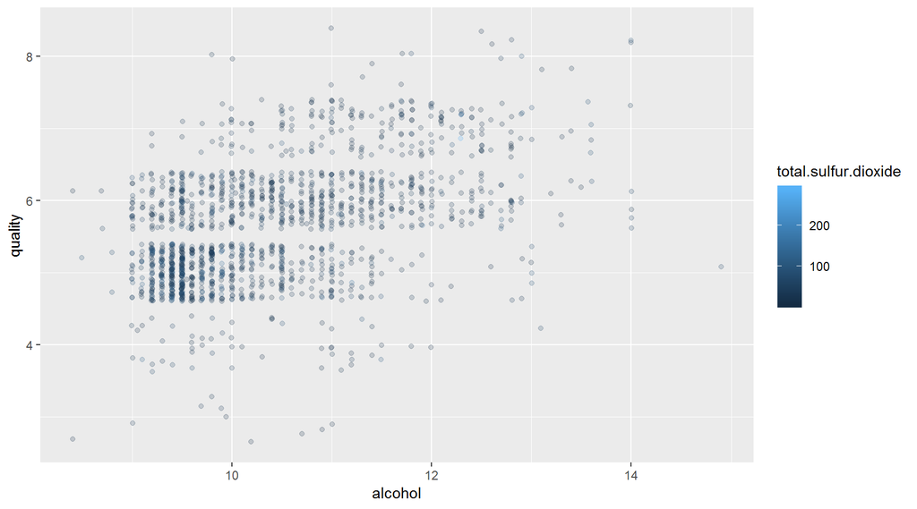

Here we see the quality and alcohol scatterplot, colored with total sulfur dioxide relation that improve our intuition of total sulfur dioxide feature with both of alcohol and quality. for the above figures, i tried different combinations of different variables to get a better intuition of how they merge together.

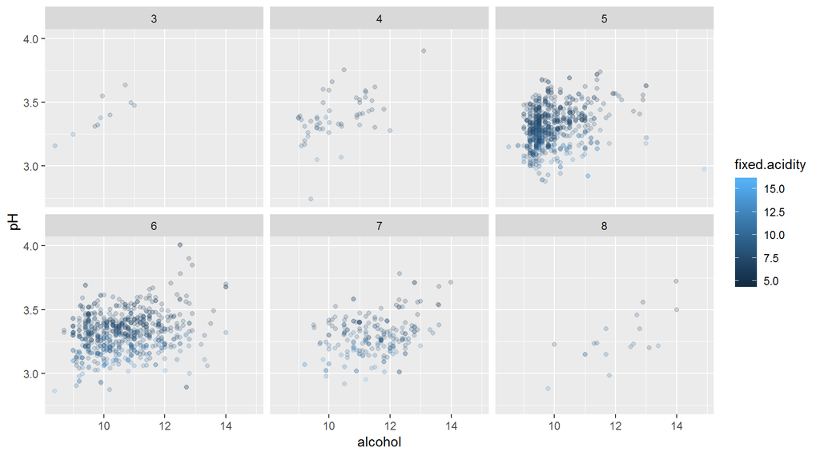

For the pH and alcohol scatterplot, colored with fixed acidity and wraped with quality we can distinguish between values for different wine quality

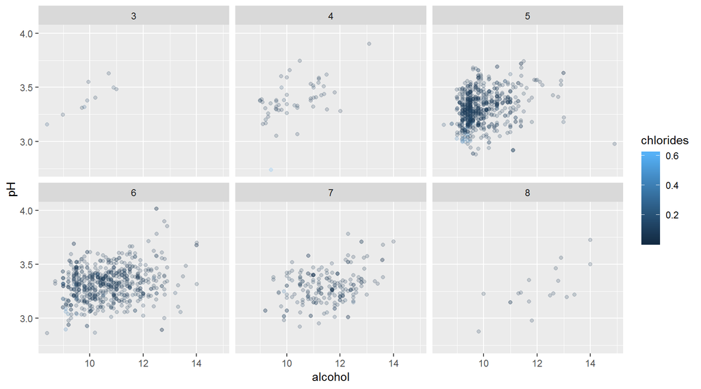

same as above with different features

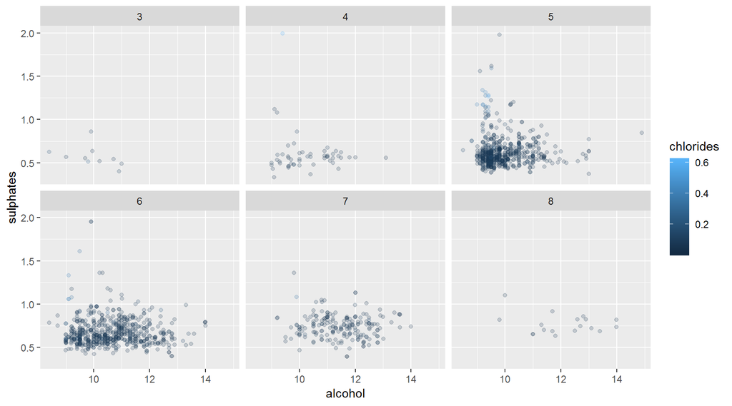

same as above with different features.

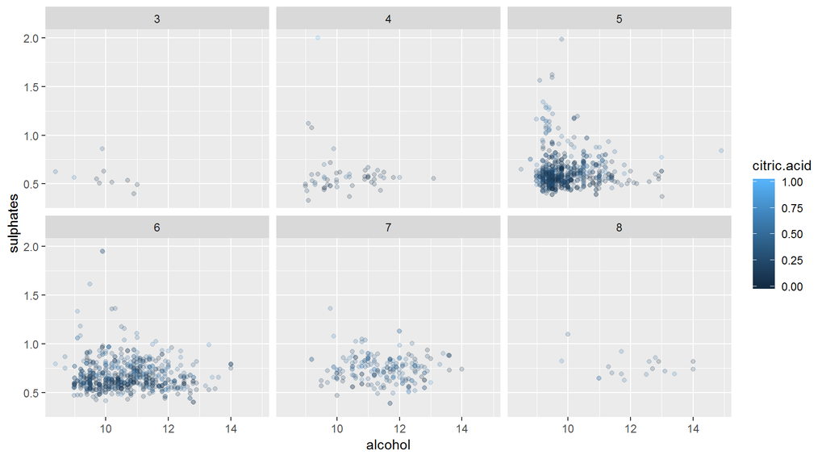

I make facet wrap using quality, as it’s the only integer variable, that we can observe as a result for different features or parameters together.

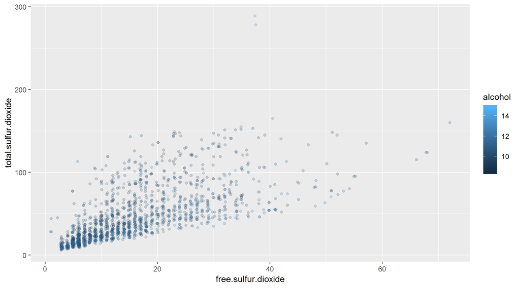

free sulfur dioxide is strongly correlated with total sulfur dioxide, i used alcohol to color different dots.

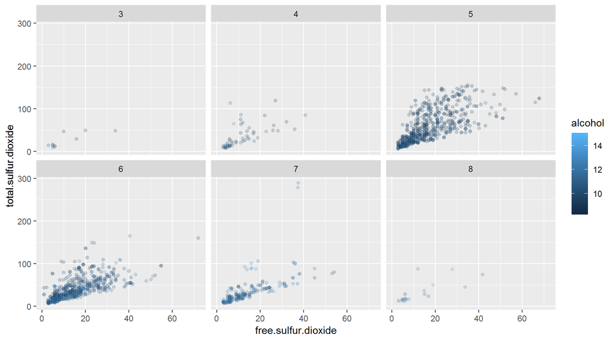

By adding facet wrap using quality, it’s clear the effect of these features on wine quality.